# Project 3 Documentation

AdamMalachiJD

October 16, 2015

For this project we used our previous CSV, contaning data from many stars throughout the Universe. In addition to this CSV, we included another that contained data corresponding to the stellar spectrum classification each star possessed along with the Hexadecimal color code of the star. We used these two CSVs for the first two visuals.

1.) The first visual comes from doing a full join of the two datasets previously mentioned, taking the previous attributes of the stars and combining the stellar spectrum classification.

This visual shows the density of particular segments of the spectrum classification across the different constellations. Visually, one can see the variation in the stellar spectrum across each constellation, seeing that some harbor a wide range, while some are clustered.

```r
source("../02 Data Wrangling/Workflow1.R", echo = TRUE)
```

[output not shown]

```
##
## > require("RCurl")
```

```
##
## > require("ggplot2")
```

```
##
## > require("dplyr")
```

```
##
## > MainDF <- data.frame(fromJSON(getURL(URLencode("129.152.144.84:5001/rest/native/?query=\"select * from HYGSTARDATA\""),
## +     httpheader = c(DB = " ..." ... [TRUNCATED]
##
## > SCDF <- data.frame(fromJSON(getURL(URLencode("129.152.144.84:5001/rest/native/?query=\"select * from STARSUBCLASS10k\""),
## +     httpheader = c(DB = .... [TRUNCATED]
##
## > for (n in names(SCDF)) {
## +     SCDF[n] <- data.frame(lapply(SCDF[n], gsub, pattern = "[\\( - \\)]",
## +         replacement = ""))
## +     SCDF[n] <- d .... [TRUNCATED]
##
## > df <- select(MainDF, ID, SPECT, CON)
##
## > for (n in names(df)) {
## +     df[n] <- data.frame(lapply(df[n], gsub, pattern = "(/[A-Z][0-9]I*)",
## +         replacement = ""))
## + }
##
## > for (n in names(df)) {
## +     df[n] <- data.frame(lapply(df[n], gsub, pattern = "(-I*)|(-V)|(-IV)",
## +         replacement = ""))
## + }
##
## > for (n in names(df)) {
## +     df[n] <- data.frame(lapply(df[n], gsub, pattern = "(/I*)|(/V)|(/IV)",
## +         replacement = ""))
## + }
##
## > SCDF <- rename(SCDF, SPECT = CLASS)
##
## > SCDF2 <- select(SCDF, SPECT, HEX)
##
## > HABdf <- full_join(df, SCDF2, by = "SPECT")
```

```
##
## > require(extrafont)
```

```
## Registering fonts with R
```

```
##
## > ggplot() + coord_cartesian() + scale_x_discrete() +
## +     scale_y_continuous() + labs(title = "Distribution across Color Spectrum within Constellat ..." ... [TRUNCATED]
```

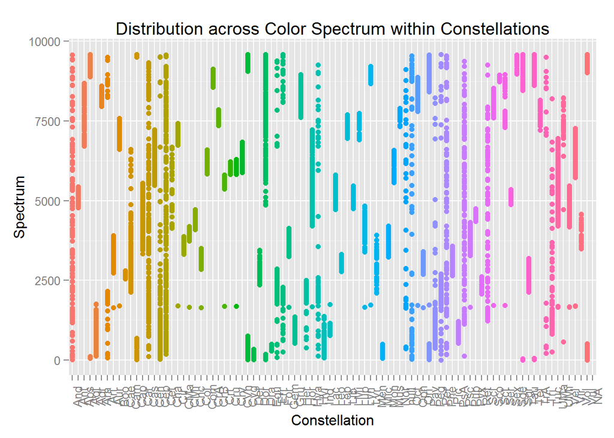

2.) This Dataset combines two datasets: the HYG combined bright star catalog, and a dataset which details the hex code for each stellar spectrum classification.

I used these two datasets to assign a hex code value to every star in the database which had a spectrum classification.

I was then able to manipulate the ggplot manual legend function to assign a color to each spectrum based on its hex code.

The resulting dataset displays the exact color of each star. The data is displayed in a way that shows each constellations spectral distribution.

```r
source("../02 Data Wrangling/Workflow2.R", echo = TRUE)
```

```
##
## > require(tidyr)
```

[output not shown]

[output cut: 53 more lines]

[output not shown]

```
##
## > jdf <- jdf %>% filter(SPECT != "", !is.na(HEX)) %>%
## +     arrange(SPECT) %>% distinct()
##
## > head(jdf)
##      ID SPECT CON     HEX
## 1 30275    A0 Aur #bbceff
## 2 38008    A0 Cep #bbceff
## 3 93482    A0 Lyr #bbceff
## 4   677    A0 Cas #bbceff
## 5 12024    A0 Cet #bbceff
## 6 18930    A0 Eri #bbceff
##
## > hexdf <- jdf["HEX"]
##
## > hexdf <- distinct(hexdf)
##
## > hexdf <- hexdf[, "HEX"]
##
## > require(extrafont)
##
## > ggplot() + coord_cartesian() + scale_x_discrete() +
## +     scale_y_discrete() + scale_color_manual(values = c(as.character(hexdf))) +
## +     labs(ti .... [TRUNCATED]
```

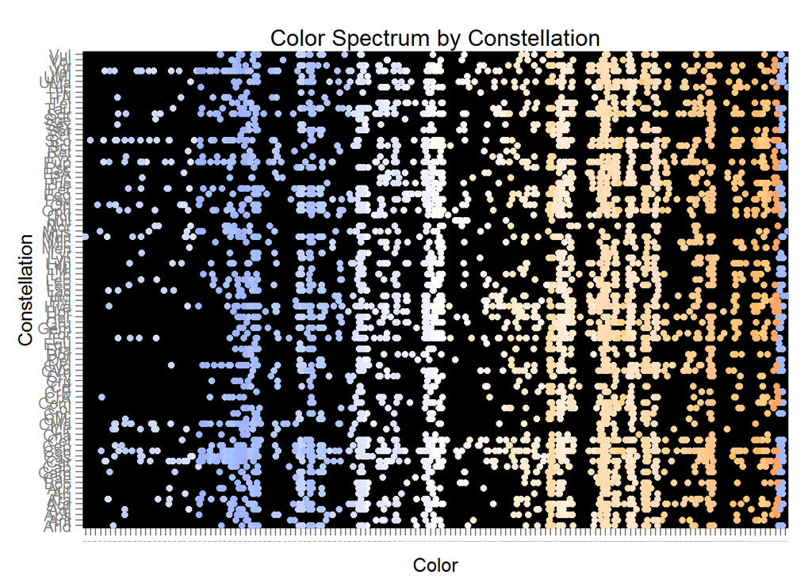